# Clustering

Matt Goard

3/18/2022

# `kmeans()` Function

The `kmeans()` function is useful in predicting different variable types. The easiest way for me to explain this function is to describe every input.

It is important to note that when this function is called, because it is a prediction function, prediction needs to be random. This means you need to set a seed using `set.seed()`.

The function is called in this style:

`kmeans(x, centers, iter.max = 10, nstart = 1, algorithm = c("Hartigan-Wong", "Lloyd", "Forgy", MacQueen"), trace = FALSE))`

## `x`

This is simply the data frame that you use to predict clusters.

## `centers`

This just means the number of clusters or groups that you want the function to predict. So if you’re predicting pitch types, how many pitches do you want the function to predict?

## `iter.max`

This is how many times that the function runs through the data to try and predict clusters. Basically the default setting of the function is it double checks itself 10 times.

## `nstart`

The clusters need to be random, so this tells the function how many random sets are chosen.

## `algorithm`

Honestly, I know this will change the results, somehow, or the method that the function uses to get the results which could cause different results than another algorithm, but I don’t know if this matters.

# What Does `kmeans()` Return?

It returns a lot of stuff honestly. Let’s go through each individually.

## `totts`

Total sum of squares. So basically the total error.

## `withinss`

Basically this is a vector of all errors within each individual cluster.

## `tot.withinss`

Basically each of the entries of `withinss` summed up. This is different than the `totts` though so don’t get the two confused.

## `betweenss`

This is the difference between `totts` and `tot.withinss`, so

$$betweenss = totts-
tot.withinss$$

## `size`

How many of each cluster are found.

## `iter`

The number of times the clustering was repeated.

# Example

I was given the Trackman data for three former pitchers at Vanderbilt University. I was asked to play with the `kmeans()` function to find interesting predictors for pitch type. So, let’s dive in.

I decided to use predictors other than `RelSpeed`, `Tilt`, and `SpinRate` because those are the variables that we use when actually tagging. I honestly thought that would be boring to look at. Outside of those however, there are few variables to use in predicting solely based on the metrics of the pitch. For the purpose of this assignment, I am only looking at predictors that are not dependent on the result of the play.

Should I have time, I will be interested in looking at result of the play to determine `PitchType` because that can identify a pitcher’s “weak pitches.” This would allow an understanding of what pitches they are more likely to throw for a ball, strike, out, or get a hit off of.

## Vanderbilt Pitcher 1

For the first pitcher, I decided to look at the count and outs to determine what pitch would be thrown. Before getting to a higher level of baseball, it was common to see a pattern in pitch sequencing, where fastballs would mostly be thrown until a strikeout count where a curveball was then thrown. However, one you reached high school this was a lot less common and you could get any pitch at any time.

```r
Vandy1 <- data.table::fread("/home/students/goardmm/SportsAnalyticsClass/Assignment4/vandy_1.csv")
set.seed(7)
pitch_cluster1 <- kmeans(Vandy1[,c(2, 3, 4)], 6, nstart = 20)
pitch_cluster1
```

```
## K-means clustering with 6 clusters of sizes 51, 115, 79, 98, 64, 59
##
## Cluster means:
##        Outs     Balls   Strikes
## 1 2.0000000 2.3333333 1.3529412
## 2 1.5043478 0.3304348 0.0000000
## 3 0.7974684 0.6582278 1.5063291
## 4 0.0000000 0.5102041 0.2959184
## 5 0.6562500 2.2968750 1.4687500
## 6 2.0000000 0.4915254 1.4237288
##
## Clustering vector:
##   [1] 4 4 4 5 5 2 2 5 5 5 2 6 6 6 6 1 4 4 4 3 5 5 5 2 2 3 5 2 6 6 6 4 4 4 3 2 3
##  [38] 3 5 5 2 6 6 1 1 1 2 2 1 1 1 2 2 1 1 2 2 6 6 4 4 4 5 5 5 2 2 3 3 5 5 2 2 6
##  [75] 6 6 4 4 4 4 4 4 2 3 2 6 6 6 4 2 3 3 2 2 6 1 1 2 2 6 1 1 4 4 4 2 3 3 5 2 3
## [112] 3 3 3 5 5 5 5 2 2 3 3 3 5 2 3 3 3 2 6 6 1 1 4 4 5 5 4 4 4 5 5 2 3 3 3 5 2
## [149] 3 3 2 6 6 6 4 4 3 2 2 2 6 6 6 6 1 1 1 4 4 4 5 5 2 3 3 2 6 6 6 1 1 1 4 4 4
## [186] 4 4 4 2 2 3 3 2 2 1 1 1 1 4 4 4 2 2 3 5 4 4 3 3 2 3 3 2 2 6 6 4 4 4 4 2 2
## [223] 3 2 2 1 1 1 1 1 2 6 4 4 4 5 5 5 4 2 2 3 3 3 5 5 5 2 2 1 1 1 1 2 6 6 4 4 4
## [260] 2 2 5 5 5 2 6 6 6 2 6 6 4 4 3 4 4 4 5 2 2 3 5 5 5 4 4 2 2 3 3 3 5 5 2 3 2
## [297] 2 3 3 5 5 2 2 6 1 1 2 6 6 1 4 4 4 4 2 3 3 5 5 5 5 5 2 2 6 1 1 1 1 4 4 3 2
## [334] 3 3 3 3 2 2 6 6 4 4 3 3 3 2 2 5 5 2 2 3 3 2 3 3 2 2 3 5 5 2 2 6 1 1 1 4 4
## [371] 4 3 5 2 2 3 3 2 2 2 6 2 2 2 6 2 2 6 6 1 1 1 1 4 4 4 2 3 3 3 2 6 6 6 4 4 2
## [408] 3 3 5 5 2 4 4 4 3 2 2 3 3 5 5 2 2 4 4 3 3 5 2 2 2 1 1 1 4 4 4 4 4 4 4 3 4
## [445] 4 4 3 2 2 2 2 6 6 6 2 2 6 4 4 4 5 5 4 4 4 2
##
## Within cluster sum of squares by cluster:
## [1] 36.98039 54.19130 50.27848 62.90816 53.73438 29.15254
##  (between_SS / total_SS =  72.2 %)
##
## Available components:
##
## [1] "cluster"      "centers"      "totss"        "withinss"     "tot.withinss"
## [6] "betweenss"    "size"         "iter"         "ifault"
```

```r
table(pitch_cluster1$cluster, Vandy1$AutoPitchType)## K means to determine pitch types
```

```
##
##     ChangeUp Curveball Cutter Fastball Slider Splitter
##   1        3         8      0       40      0        0
##   2       12        27      0       75      0        1
##   3        2        24      0       47      6        0
##   4        7        22      1       65      2        1
##   5        5         7      1       50      1        0
##   6        3        25      0       28      3        0
```

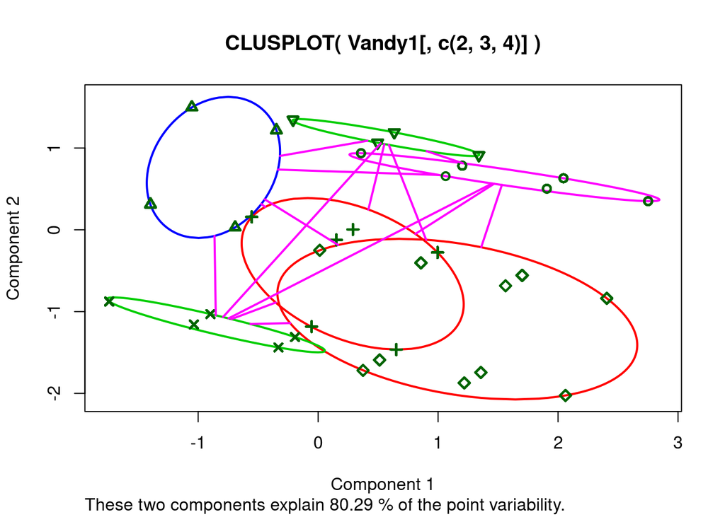

```r
library(cluster)
##png(file="kmeansPlot.png", height=500, width=650)
clusplot(Vandy1[,c(2,3,4)], pitch_cluster1$cluster, color=T, lwd=2)
```

## Vanderbilt Pitcher 2

```r
Vandy2 <- data.table::fread("/home/students/goardmm/SportsAnalyticsClass/Assignment4/vandy_2.csv")
set.seed(4)
pitch_cluster2 <- kmeans(Vandy2[,c(12, 13, 18, 19)],4,nstart = 20)
pitch_cluster2
```

```
## K-means clustering with 4 clusters of sizes 114, 173, 130, 99
##
## Cluster means:
##   RelHeight  RelSide PlateLocHeight PlateLocSide
## 1  5.500093 1.995124      1.7187293    0.6898322
## 2  5.533920 1.977051      2.0935358   -0.5462734
## 3  5.503445 1.944696      3.3188014    0.7717829
## 4  5.622550 1.949666      0.5885421   -1.3607082
##
## Clustering vector:
##   [1] 4 4 4 2 2 2 4 3 2 2 4 2 2 2 4 3 2 4 1 3 3 3 3 1 3 3 1 3 3 2 3 1 3 1 2 2 3
##  [38] 2 3 2 2 2 2 1 1 2 1 3 2 3 2 1 1 4 4 3 2 3 3 4 4 2 3 1 3 3 3 3 1 3 2 2 3 4
##  [75] 3 2 3 2 3 2 4 4 4 2 4 2 4 2 4 3 4 2 1 4 3 2 1 3 2 4 4 3 1 2 3 1 2 3 2 2 2
## [112] 2 2 4 4 2 2 1 2 3 2 3 1 3 1 2 2 4 2 3 1 3 1 1 3 3 2 1 1 2 2 2 3 3 3 3 2 3
## [149] 2 1 3 1 4 4 3 1 3 2 2 1 3 4 2 3 2 4 2 4 1 3 3 3 3 2 3 3 2 3 1 2 2 4 3 3 1
## [186] 1 2 3 1 3 2 3 1 4 1 4 1 1 4 3 2 4 1 1 4 4 1 3 2 2 2 4 1 1 2 2 2 4 3 3 3 1
## [223] 1 2 2 2 4 3 1 1 4 2 4 3 2 1 2 2 4 2 2 4 4 4 1 2 4 4 3 4 2 1 3 1 2 2 4 2 1
## [260] 4 3 2 4 1 2 1 1 1 3 2 4 4 3 3 4 1 2 2 4 4 3 3 3 2 3 3 1 1 2 1 1 1 2 4 2 4
## [297] 2 2 2 4 4 4 1 2 1 4 2 1 3 1 4 3 1 2 4 2 4 4 2 3 2 2 4 2 1 2 2 2 2 4 1 2 2
## [334] 2 4 3 2 3 3 3 3 3 1 1 3 2 2 2 2 2 3 3 3 2 1 1 3 2 4 2 3 2 2 3 2 3 1 2 2 1
## [371] 2 2 2 2 4 4 3 2 4 1 3 1 3 1 3 1 2 3 2 2 2 2 4 1 2 4 4 2 4 3 2 2 3 3 3 1 1
## [408] 1 1 1 2 2 4 1 4 2 1 1 3 2 3 3 1 1 2 1 3 4 2 1 1 1 1 4 2 4 4 2 1 1 2 4 2 1
## [445] 4 1 1 1 3 1 3 3 2 2 1 1 3 3 2 2 3 1 2 4 1 2 3 1 1 2 2 2 2 3 2 2 4 4 3 3 1
## [482] 2 4 1 2 1 3 1 3 4 2 3 2 4 2 4 2 4 2 3 3 2 4 2 3 3 3 1 4 1 2 4 1 4 4 2
##
## Within cluster sum of squares by cluster:
## [1]  62.21486 100.33558 129.81970  94.01371
##  (between_SS / total_SS =  67.3 %)
##
## Available components:
##
## [1] "cluster"      "centers"      "totss"        "withinss"     "tot.withinss"
## [6] "betweenss"    "size"         "iter"         "ifault"
```

```r
table(pitch_cluster2$cluster, Vandy2$AutoPitchType)## K means to determine pitch types
```

```
##
##     ChangeUp Fastball Other Slider
##   1        3       87     1     23
##   2        7      101     0     65
##   3       11       86     0     33
##   4        8       18     1     72
```

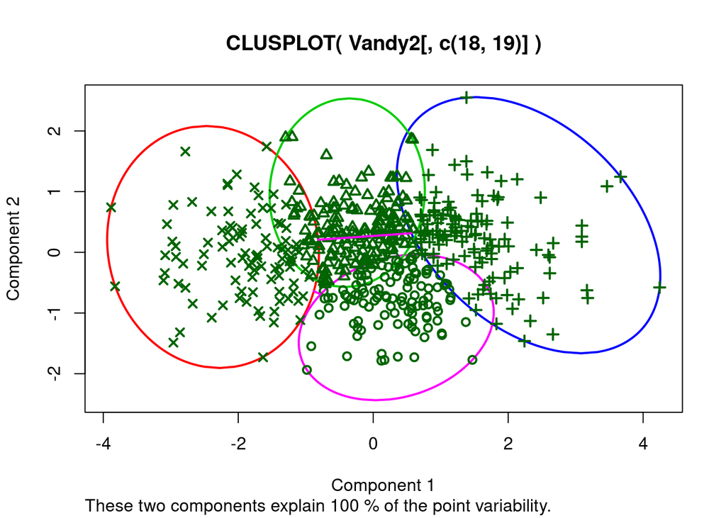

```r
library(cluster)
##png(file="kmeansPlot.png", height=500, width=650)
clusplot(Vandy2[,c(18,19)], pitch_cluster2$cluster, color=T, lwd=2)
```

## Vanderbilt Pitcher 3

I next decided to look at how much movement a pitch has to determine `PitchType`. Pitch movement explains 99.75/% of variability which is really accurate in my opinion. In looking at the relative accuracy, it is 97.4/% accurate which is incredible, meaning this pitcher’s movement is incredibly consistent.

```r
Vandy3 <- data.table::fread("/home/students/goardmm/SportsAnalyticsClass/Assignment4/vandy_3.csv")
set.seed(45)
pitch_cluster3 <- kmeans(Vandy3[,c(15, 16, 17)],6,nstart = 20)
pitch_cluster3
```

```
## K-means clustering with 6 clusters of sizes 92, 81, 57, 34, 137, 73
##
## Cluster means:
##   VertBreak InducedVertBreak HorzBreak
## 1 -12.24030        19.030254  6.647529
## 2 -43.97950        -3.308971 -2.357312
## 3 -18.47787        13.597191 11.943934
## 4 -26.27977        10.036032 12.557784
## 5 -15.49708        16.029879  8.668303
## 6 -49.60108        -6.050958 -4.646737
##
## Clustering vector:
##   [1] 3 1 1 5 6 2 6 1 6 5 5 1 1 1 6 6 5 2 1 1 5 6 5 5 5 1 4 5 5 1 6 1 5 5 1 6 5
##  [38] 5 5 1 6 6 5 6 5 6 5 5 3 6 6 6 2 4 5 1 6 5 5 4 4 4 5 6 1 5 5 5 3 6 5 5 6 1
##  [75] 5 4 5 5 6 6 5 5 6 3 5 6 1 6 5 3 6 3 4 3 3 6 6 5 6 3 5 5 5 1 4 5 3 5 2 1 6
## [112] 1 5 5 6 1 5 5 6 3 5 6 5 5 6 4 3 3 3 4 3 6 4 6 3 3 6 4 5 6 4 6 5 6 4 1 5 3
## [149] 5 6 5 5 5 6 5 1 5 1 1 5 6 6 6 6 1 5 5 5 1 1 2 6 1 5 2 2 5 5 5 6 1 1 6 2 6
## [186] 6 6 5 6 6 1 2 5 1 2 6 1 5 5 6 6 5 4 5 5 5 2 2 1 2 5 1 5 5 4 4 2 1 2 2 1 5
## [223] 5 5 1 4 5 3 1 2 2 1 2 4 1 5 1 1 5 2 1 5 4 2 5 1 2 4 5 2 2 1 2 2 5 4 1 1 1
## [260] 1 1 2 2 1 1 1 1 2 2 5 4 5 6 2 4 4 3 5 5 1 5 4 1 2 5 1 1 6 1 3 4 6 5 5 1 6
## [297] 6 4 1 2 2 1 5 2 5 4 3 5 2 5 5 5 1 3 3 3 5 5 2 5 5 4 2 3 5 2 5 3 3 6 5 5 5
## [334] 6 5 3 5 2 2 5 1 2 2 5 1 5 3 3 3 2 3 5 3 3 2 1 2 2 1 4 3 1 6 3 2 5 3 3 3 3
## [371] 3 5 3 6 3 3 2 3 3 6 2 2 2 2 5 3 5 2 1 3 1 2 1 2 1 1 2 2 2 5 4 2 5 2 1 2 1
## [408] 1 5 4 2 2 2 1 1 5 5 6 6 5 3 5 6 2 2 3 1 2 1 5 6 5 5 3 5 1 3 2 2 2 3 5 5 5
## [445] 2 2 2 6 6 1 2 1 4 1 6 1 1 2 5 2 2 1 2 2 1 3 1 3 3 1 5 2 5 5
##
## Within cluster sum of squares by cluster:
## [1] 729.5369 847.0492 357.9284 862.6136 829.9605 895.0061
##  (between_SS / total_SS =  97.4 %)
##
## Available components:
##
## [1] "cluster"      "centers"      "totss"        "withinss"     "tot.withinss"
## [6] "betweenss"    "size"         "iter"         "ifault"
```

```r
table(pitch_cluster3$cluster, Vandy3$AutoPitchType)## K means to determine pitch types
```

```
##
##     ChangeUp Curveball Fastball Other Slider Splitter
##   1        0         0       92     0      0        0
##   2        0        29        0     0     52        0
##   3        1         0       56     0      0        0
##   4       30         0        1     1      1        1
##   5        0         0      137     0      0        0
##   6        0        71        0     0      2        0
```

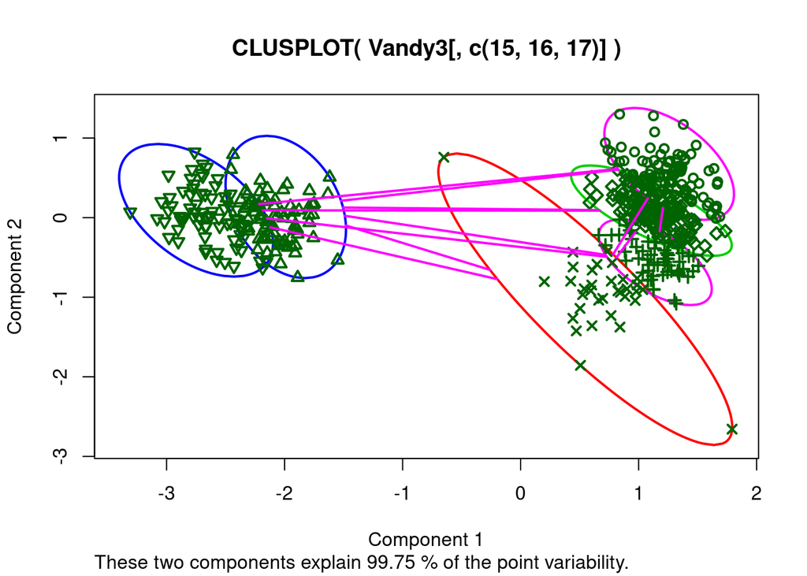

```r
library(cluster)
##png(file="kmeansPlot.png", height=500, width=650)
clusplot(Vandy3[,c(15,16,17)], pitch_cluster3$cluster, color=T, lwd=2)
```